# datasets::cars데이터 셋을 이용하여 속도에 대한 제동거리의 산점도와 적합도(신뢰구간 그래프)를 나타내시오(단, 속도가 5부터 20까지 제동거리 0부터 100까지만 그래프에 나타냄).

# 7. gapminder::gapminder 데이터 셋에서 북한과 한국의 년도별 GDP 변화를 산점도로 시각화하시오(북한:Korea, Dem. Rep. 한국:Korea, Rep. substr(str, start, end)함수 이용)

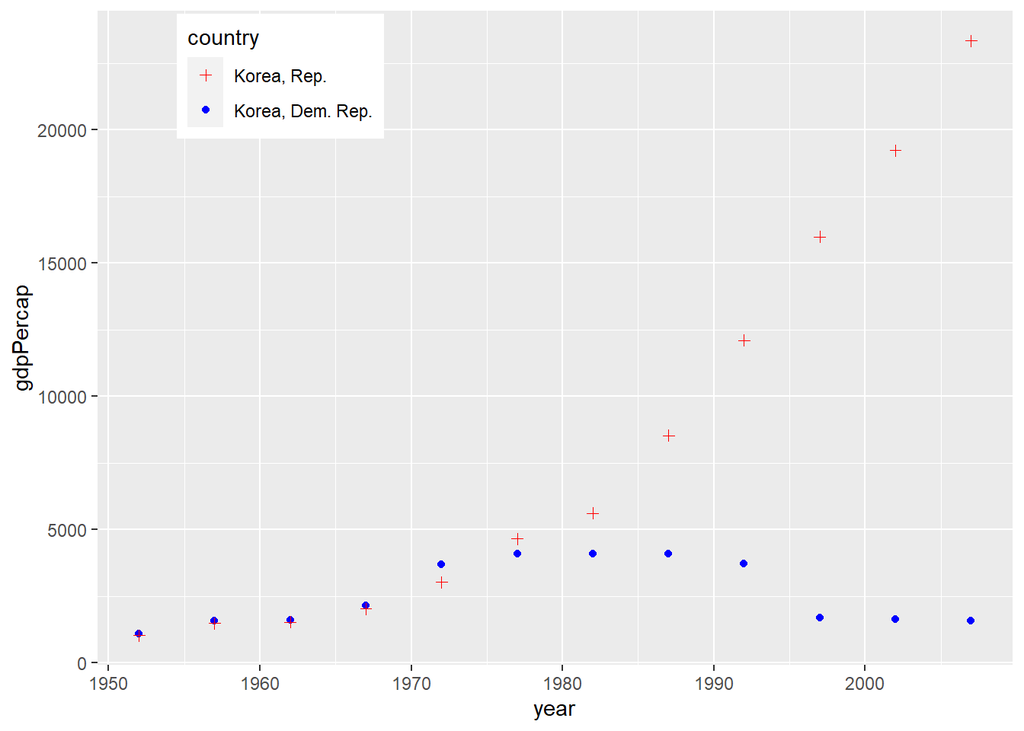

```r
gapminder2 <- gapminder

gapminder2$country <- factor(gapminder2$country, levels = rev(levels(gapminder2$country)))

gapminder2 %>%
  filter(country == 'Korea, Rep.' | country == 'Korea, Dem. Rep.') %>%
  arrange(desc(country)) %>%
  ggplot(aes(x=year, y=gdpPercap, shape=country)) +
  geom_point(aes(color=country), stat='identity') +
  scale_color_manual(values = c('red','blue'))  +
  scale_shape_manual(values=c(3, 19)) +
  theme(legend.position = c(0.2,0.9))
```

# 8. gapminder::gapminder 데이터 셋을 이용하여 한중일 4개국별 GDP 변화를 산점도와 추세선으로 시각화 하시오.

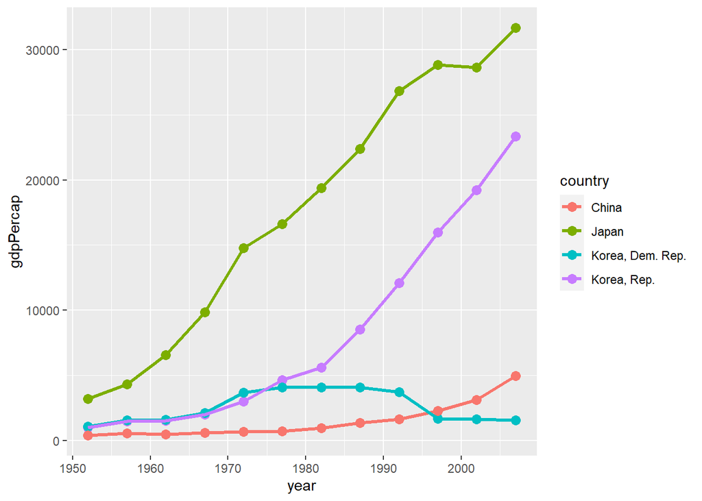

```r
gapminder %>%
  filter(country == 'Korea, Rep.' | country == 'Korea, Dem. Rep.' | country == 'Japan' | country == 'China') %>%
  arrange(desc(country)) %>%
  ggplot(aes(x=year, y=gdpPercap)) +
  geom_point(aes(color=country), stat='identity', size=3)  +
  geom_line(aes(color=country), stat='identity', size=1.1 )
```

# 9. gapminder::gapminder 데이터 셋에서 한중일 4개국별 인구변화 변화를 산점도와 추세선으로 시각화 하시오(scale_y_continuous(labels = scales::comma)추가시 우측처럼)

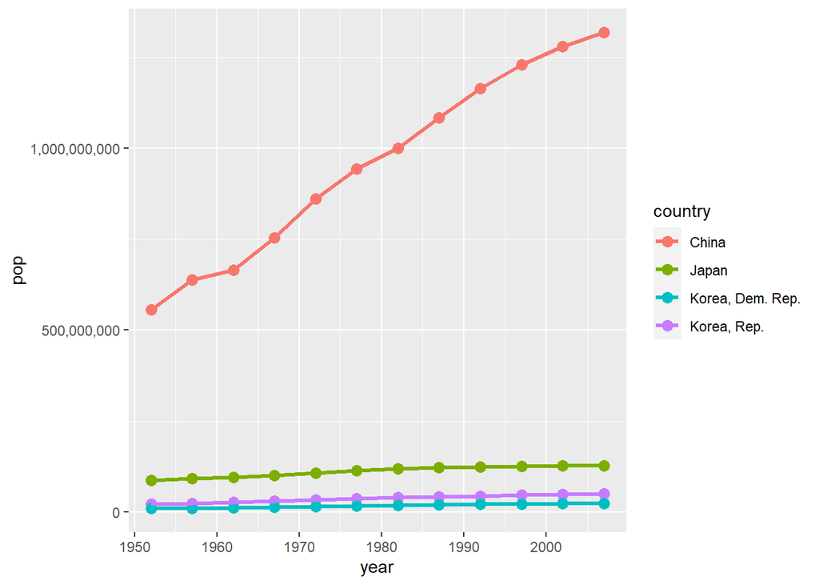

```r
gapminder %>%
  filter(country == 'Korea, Rep.' | country == 'Korea, Dem. Rep.' | country == 'Japan' | country == 'China') %>%
  arrange(desc(country)) %>%
  ggplot(aes(x=year, y=pop)) +
  geom_point(aes(color=country), stat='identity', size=3)  +
  geom_line(aes(color=country), stat='identity', size=1.1 ) +
  scale_y_continuous(labels = scales::comma)
```

# 10.Ggplot2::economic 데이터 셋의 개인 저축률(psavert)가 시간에 따라 어떻게 변해 왔는지 알아보려 한다. 시간에 따른 개인 저축률의 변화를 나타낸 시계열 그래프와 추세선을 시각화하시오

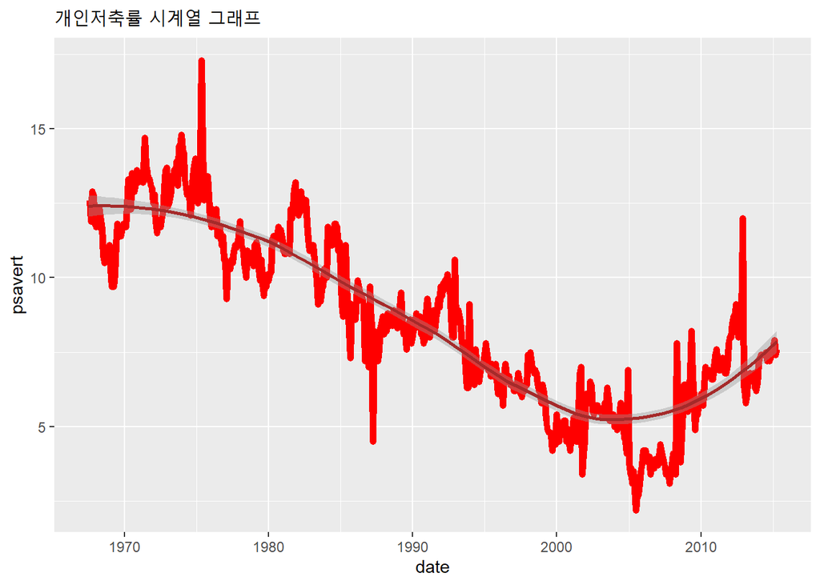

```r
ggplot(economics, aes(x=date, y=psavert)) +
  geom_line(color='red', size=2) +
  geom_smooth(color='brown') +
  labs(title='개인저축률 시계열 그래프', x="date")
```